# Eficácia da Análise de Sentimento baseada em Léxicos

```r
library(tidyverse)
library(here)
library(modelr)
library(broom)
library(GGally)
theme_set(theme_bw())
```

### Motivação

Segundo os levantamentos do Instituto Brasileiro de Geografia e Estatística (IBGE), o Brasil possui atualmente mais de 207 milhões de habitantes. O Governo Federal tem dificuldades para atender reclamações dos cidadãos, seja por conta do alto número de habitantes por município, como também por consequência dos inúmeros problemas de infraestrutura que o país possui.

Diante desta situação, o Governo Federal precisa estimar o nível de insatisfação das reclamações para que possa gerenciar melhor as ações que devem ser tomadas para sanar os problemas. Entretanto, realizar estas estimativas não é uma tarefa fácil: é necessário um método aplicável para análise de sentimento nas reclamações.

Um dos métodos mais utilizados neste ramo é a análise de sentimento baseada em léxicos, que consiste no uso de um dicionário de palavras e frases que, ao invés de possuir significado, possui uma qualificação numérica. Este tipo de análise é considerada muito eficiente, seja na utilização de recursos computacionais, seja em capacidade de predição.

Sendo assim, queremos nessa pesquisa quantificar a eficácia dos métodos de análise de sentimento baseados em léxicos para estimar o nível de insatisfação das reclamações que o Governo Federal recebe através do ReclameAqui, um portal de reclamações de âmbito geral.

### Perguntas de pesquisa

- Quão eficazes são os métodos de análise de sentimento baseados em léxicos para estimar o nível de insatisfação de reclamações recebidas pelo ReclameAqui do governo federal?
- Há relação entre o comprimento de cada reclamação e o nível de insatisfação atribuído?
- Considerando os órgãos e o erro, qual dos dois léxicos (op30 ou sent) mostrou-se mais eficiente ao tentar estimar o nível de insatisfação?

## Os dados

Os dados são compostos por uma amostra das reclamações feitas por usuários dos órgãos federais, em nosso caso, são especificamente INSS e ANAC. Essas reclamações foram submetidas a plataforma ReclameAqui. A partir dessa amostra, foi feito avaliações quanto ao nível de insatisfação da pessoa com o órgão, sendo 320 avaliações feitas por 60 alunos do curso de Ciência da Computação da Universidade Federal de Campina Grande.

```r
reclamacoes = read_csv(here("data/3-avaliacao-humana/reclamacoes-avaliadas-20180703.csv"))
sentimentos = read_csv(here("data/5-sentimentos/sentimento.csv"))

reclamacoes = reclamacoes %>% mutate(comprimento_reclamacao = str_length(reclamacao))
```

`reclamacoes_l` tem um formato long em vez de wide (explicado [aqui](https://sejdemyr.github.io/r-tutorials/basics/wide-and-long/)).

### Reunindo os dados em uma única tabela

Em reclamações temos os dados referentes as reclamações dos usuários. Em sentimentos está contido as avaliações feitas pelas ferramentas op30 e sent, assim como o a classificação manual.

```r
reclamacoes = reclamacoes %>%
    left_join(sentimentos, by = "id")
reclamacoes_l = reclamacoes %>%
    select(-palavras_op30, -palavras_sent, -grupo_avaliando) %>%
    gather(key = "lexico",
           value = "polaridade",
           sentimento_op30, sentimento_sent)
reclamacoes_l %>% View()
```

```r
 #Faça você mesmo. Crie a variável polaridade_normalizada
 reclamacoes_l = reclamacoes_l %>%
     group_by(lexico) %>%
     mutate(polaridade_normalizada = round((polaridade - min(polaridade)) / max(polaridade - min(polaridade)) * (1 - 5) + 5))
```

Calcula o erro (SSE) por reclamação

```r
reclamacoes_l = reclamacoes_l %>%
    mutate(erro = (insatisfacao - polaridade_normalizada)**2)
```

### Como avaliar a eficácia dos métodos?

Uma medida interessante da eficiência desses métodos é calcular a soma dos erros ao quadrado (SSE) considerando o que o método definiu como a polaridade_normalizada e o que a avaliação humana definiu como a insatisfação.

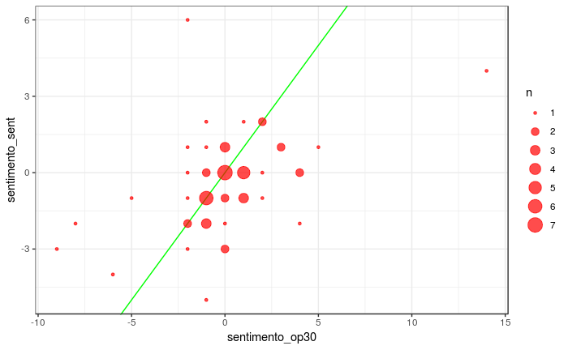

```r
reclamacoes %>%
    ggplot(aes(x = sentimento_op30, y = sentimento_sent)) +
    geom_abline(slope = 1, intercept = 0, color = "green") +
    geom_count(alpha = .7, color = "red")
```

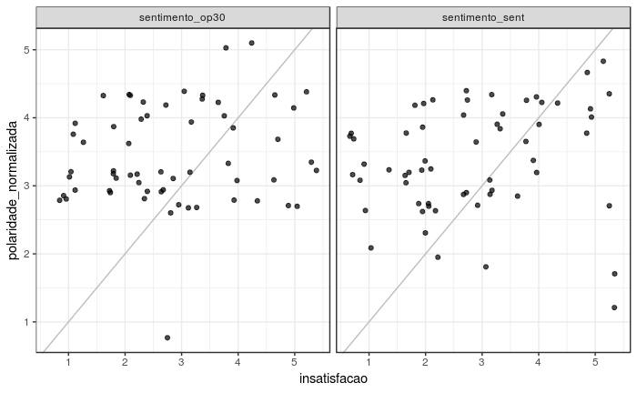

```r
reclamacoes_l %>%
    ggplot(aes(x = insatisfacao, y = polaridade_normalizada, group = insatisfacao)) +
    geom_abline(slope = 1, intercept = 0, color = "grey") +
    geom_jitter(alpha = .7)  +
    facet_wrap(~ lexico)
```

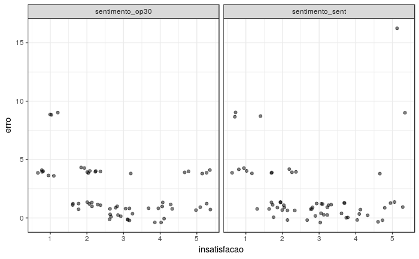

```r
reclamacoes_l %>%
    ggplot(aes(x = insatisfacao, y = erro, group = insatisfacao)) +
    geom_jitter(alpha = .5)  +
    # geom_boxplot() +
    facet_wrap(~ lexico)
```

## Há relação entre o número de palavras e o nível de insatisfação atribuído?

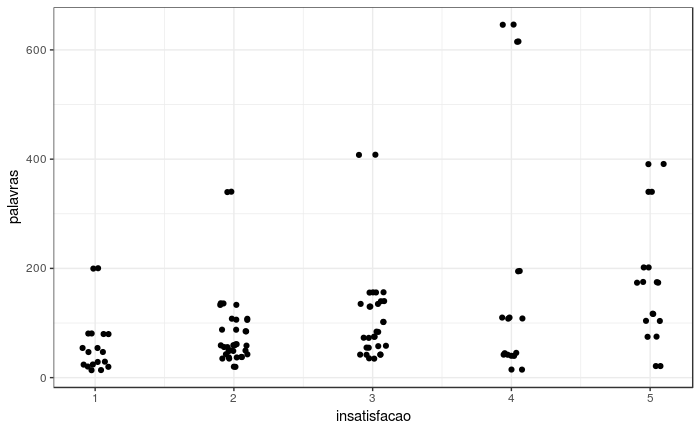

```r
reclamacoes_l %>%
  ggplot(aes(x = insatisfacao, y = palavras)) +
  geom_jitter(width = .1)
```